# Investigation of various approach to constructing a consensus string

```r
Sys.time()
```

```
## [1] "2015-03-12 14:56:59 SAST"
```

## Overview

Three important steps needs to be optimized:

- mislabel classification
- alignment
- consensus string construction

This document investigates all three steps simultaneously by a simulation process:

- Given an input string and a read error profile
- Potentatially given a contamination string
- Simulate reads from both strings and form a bin
- Use mislabel classification to throw out outliers
- Align the remaining sequences
- Construct a final sequence
- Compare the reconstructed sequence to the input sequence with edit distance

We need very clear terminology to keep track of the different aspects of the simulations:

- All the parameters that goes into the three steps are called a 'setup'
- A input sequence, number of reads, contamination sequence, number of contamination reads and the error profile is called a 'scenario' or 'test scenario'.
- A test scenario, setup and a seed is called a 'case' or 'test case'.

## The setups

```r
setups <- list()
setups[['base']] <- list(classification_technique = 'infovar_balance',
                         classification_params = list(threshold = 1),
                         alignment_technique = 'muscle',
                         alignment_params = list(),
                         consensus_technique = 'Biostrings::consensusString',
                         consensus_params = list(ambiguityMap = 'N'))

setups[['base1']] <- list(classification_technique = 'infovar_balance',
                         classification_params = list(threshold = 1,
                                          start_threshold = 0.02),
                         alignment_technique = 'muscle',
                         alignment_params = list(),
                         consensus_technique = 'Biostrings::consensusString',
                         consensus_params = list(ambiguityMap = 'N'))

setups[['most_con']] <- list(classification_technique = 'infovar_balance',
                         classification_params = list(threshold = 1,
                                          start_threshold = 0.02),
                         alignment_technique = 'muscle',
                         alignment_params = list(),
                         consensus_technique = 'mostConsensusString',
                         consensus_params = list())

setups[['most_abs']] <- list(classification_technique = 'absolute',
                         classification_params = list(threshold = 0.045,
                                          start_threshold = 0.045),
                         alignment_technique = 'muscle',
                         alignment_params = list(),
                         consensus_technique = 'mostConsensusString',
                         consensus_params = list())

setups_abs <- list()
setups_abs[['abs_01']] <- list(classification_technique = 'absolute',
                               classification_params = list(threshold = 0.01,
                                                start_threshold = 0.01),
                               alignment_technique = 'muscle',
                               alignment_params = list(),
                               consensus_technique = 'mostConsensusString',
                               consensus_params = list())

setups_abs[['abs_02']] <- list(classification_technique = 'absolute',
                               classification_params = list(threshold = 0.02,
                                                start_threshold = 0.02),
                               alignment_technique = 'muscle',
                               alignment_params = list(),
                               consensus_technique = 'mostConsensusString',
                               consensus_params = list())

setups_abs[['abs_05']] <- list(classification_technique = 'absolute',
                               classification_params = list(threshold = 0.05,
                                                start_threshold = 0.05),
                               alignment_technique = 'muscle',
                               alignment_params = list(),
                               consensus_technique = 'mostConsensusString',
                               consensus_params = list())

setups_abs[['abs_10']] <- list(classification_technique = 'absolute',
                               classification_params = list(threshold = 0.10,
                                                start_threshold = 0.10),
                               alignment_technique = 'muscle',
                               alignment_params = list(),
                               consensus_technique = 'mostConsensusString',
                               consensus_params = list())

setups_abs[['abs_50']] <- list(classification_technique = 'absolute',
                               classification_params = list(threshold = 0.50,
                                                start_threshold = 0.50),
                               alignment_technique = 'muscle',
                               alignment_params = list(),
                               consensus_technique = 'mostConsensusString',
                               consensus_params = list())
```

## The error profiles

### Three very basic error profiles

```r
err_profiles <- list()

x <- list(read_len = 1000,
          A_err_rates = list('A' = 0.997, 'C' = 0.001, 'G' = 0.001, 'T' = 0.001),
          C_err_rates = list('C' = 0.997, 'A' = 0.001, 'G' = 0.001, 'T' = 0.001),
          G_err_rates = list('G' = 0.997, 'C' = 0.001, 'A' = 0.001, 'T' = 0.001),
          T_err_rates = list('T' = 0.997, 'C' = 0.001, 'G' = 0.001, 'A' = 0.001))
params <- list()
params[['params']] <- x
params[['technique']] <- 'uniform'
err_profiles[['unif_1_1000']] <- do.call(gen_error_profile, params)


x <- list(read_len = 1000,
          A_err_rates = list('A' = 0.97, 'C' = 0.01, 'G' = 0.01, 'T' = 0.01),
          C_err_rates = list('C' = 0.97, 'A' = 0.01, 'G' = 0.01, 'T' = 0.01),
          G_err_rates = list('G' = 0.97, 'C' = 0.01, 'A' = 0.01, 'T' = 0.01),
          T_err_rates = list('T' = 0.97, 'C' = 0.01, 'G' = 0.01, 'A' = 0.01))
params <- list()
params[['params']] <- x
params[['technique']] <- 'uniform'
err_profiles[['unif_1_100']] <- do.call(gen_error_profile, params)

x <- list(read_len = 1000,
          A_err_rates = list('A' = 0.7, 'C' = 0.1, 'G' = 0.1, 'T' = 0.1),
          C_err_rates = list('C' = 0.7, 'A' = 0.1, 'G' = 0.1, 'T' = 0.1),
          G_err_rates = list('G' = 0.7, 'C' = 0.1, 'A' = 0.1, 'T' = 0.1),
          T_err_rates = list('T' = 0.7, 'C' = 0.1, 'G' = 0.1, 'A' = 0.1))
params <- list()
params[['params']] <- x
params[['technique']] <- 'uniform'
err_profiles[['unif_1_10']] <- do.call(gen_error_profile, params)
```

## The test scenarios

```r
scenarios <- list()
scenarios[['unif_read_1']] <- list(name = 'unif_read_1',
                                   ref_seq = paste(rep('A', 500), collapse = ""),
                                   n_reads = 10,
                                   error_rates = err_profiles[['unif_1_1000']],
                                   contam_seq = NULL,
                                   n_contam = 0)
scenarios[['unif_read_2']] <- list(name = 'unif_read_2',
                                   ref_seq = paste(rep('A', 500), collapse = ""),
                                   n_reads = 10,
                                   error_rates = err_profiles[['unif_1_100']],
                                   contam_seq = NULL,
                                   n_contam = 0)
scenarios[['unif_read_3']] <- list(name = 'unif_read_3',
                                   ref_seq = paste(rep('A', 500), collapse = ""),
                                   n_reads = 10,
                                   error_rates = err_profiles[['unif_1_10']],
                                   contam_seq = NULL,
                                   n_contam = 0)

scenarios[['unif_contam_1']] <- list(name = 'unif_contam_1',
                                     ref_seq = paste(rep('A', 500), collapse = ""),
                                     n_reads = 10,
                                     error_rates = err_profiles[['unif_1_100']],
                                     contam_seq = paste(c(rep('A', 200), rep('C', 100), rep('A', 200)), collapse = ""),
                                     n_contam = 1)
scenarios[['unif_contam_2']] <- list(name = 'unif_contam_2',
                                     ref_seq = paste(rep('A', 500), collapse = ""),
                                     n_reads = 10,
                                     error_rates = err_profiles[['unif_1_100']],
                                     contam_seq = paste(c(rep('A', 200), rep('C', 100), rep('A', 200)), collapse = ""),
                                     n_contam = 5)
scenarios[['unif_contam_3']] <- list(name = 'unif_contam_3',
                                     ref_seq = paste(rep('A', 500), collapse = ""),
                                     n_reads = 10,
                                     error_rates = err_profiles[['unif_1_100']],
                                     contam_seq = paste(c(rep('A', 200), rep('C', 100), rep('A', 200)), collapse = ""),
                                     n_contam = 9)
```

## The test cases

```r
cases <- list()
seeds <- 1:3

# Note this code is gonna become complex and is going to interact with the case
# specification is weird ways - so leave it here
for (setup in names(setups)){
  for (scenario in names(scenarios)){
    for (seed in seeds){
      case_name <- paste(setup, scenario, seed, sep = '-')
      cases[[case_name]] <- list(scenario = scenarios[[scenario]],
                                 seed = seed,
                                 setup = setups[[setup]])
    }
  }
}

cases_abs <- list()
for (setup in names(setups_abs)){
  for (scenario in names(scenarios)){
    for (seed in seeds){
      case_name <- paste(setup, scenario, seed, sep = '-')
      cases_abs[[case_name]] <- list(scenario = scenarios[[scenario]],
                                 seed = seed,
                                 setup = setups_abs[[setup]])
    }
  }
}
```

## The test runner

```r
unique_scenarios <- list_unique_scenarios(cases)

cache_file <- '~/projects/MotifBinner/code/MotifBinner/inst/scenario_cache.rdata'

scenario_cache <- load_or_initialize_cache(cache_file)

scenario_cache <- create_scenario_data(unique_scenarios, scenario_cache)

save(scenario_cache, file = cache_file)
```

## Running the test cases.

```r
results <- run_all_tests(cases, scenario_cache)
results_abs <- run_all_tests(cases_abs, scenario_cache)
```

## Results: Absolute Classifier

```r
kable(results_abs)
```

| setup | scenario | seed | mismatch | input_len | output_len | mismatch_rate |
| --- | --- | --- | --- | --- | --- | --- |
| abs_01 | unif_read_1 | 1 | 0 | 500 | 0 | 0.000 |
| abs_01 | unif_read_1 | 2 | 0 | 500 | 0 | 0.000 |
| abs_01 | unif_read_1 | 3 | 0 | 500 | 0 | 0.000 |
| abs_01 | unif_read_2 | 1 | 500 | 500 | 500 | 1.000 |
| abs_01 | unif_read_2 | 2 | 500 | 500 | 500 | 1.000 |
| abs_01 | unif_read_2 | 3 | 500 | 500 | 500 | 1.000 |
| abs_01 | unif_read_3 | 1 | 500 | 500 | 500 | 1.000 |
| abs_01 | unif_read_3 | 2 | 500 | 500 | 500 | 1.000 |
| abs_01 | unif_read_3 | 3 | 500 | 500 | 500 | 1.000 |
| abs_01 | unif_contam_1 | 1 | 500 | 500 | 500 | 1.000 |
| abs_01 | unif_contam_1 | 2 | 500 | 500 | 500 | 1.000 |
| abs_01 | unif_contam_1 | 3 | 500 | 500 | 500 | 1.000 |
| abs_01 | unif_contam_2 | 1 | 500 | 500 | 500 | 1.000 |
| abs_01 | unif_contam_2 | 2 | 500 | 500 | 500 | 1.000 |
| abs_01 | unif_contam_2 | 3 | 500 | 500 | 500 | 1.000 |
| abs_01 | unif_contam_3 | 1 | 500 | 500 | 500 | 1.000 |
| abs_01 | unif_contam_3 | 2 | 500 | 500 | 500 | 1.000 |
| abs_01 | unif_contam_3 | 3 | 500 | 500 | 500 | 1.000 |
| abs_02 | unif_read_1 | 1 | 0 | 500 | 0 | 0.000 |
| abs_02 | unif_read_1 | 2 | 0 | 500 | 0 | 0.000 |
| abs_02 | unif_read_1 | 3 | 0 | 500 | 0 | 0.000 |
| abs_02 | unif_read_2 | 1 | 500 | 500 | 500 | 1.000 |
| abs_02 | unif_read_2 | 2 | 500 | 500 | 500 | 1.000 |
| abs_02 | unif_read_2 | 3 | 500 | 500 | 500 | 1.000 |
| abs_02 | unif_read_3 | 1 | 500 | 500 | 500 | 1.000 |
| abs_02 | unif_read_3 | 2 | 500 | 500 | 500 | 1.000 |
| abs_02 | unif_read_3 | 3 | 500 | 500 | 500 | 1.000 |
| abs_02 | unif_contam_1 | 1 | 500 | 500 | 500 | 1.000 |
| abs_02 | unif_contam_1 | 2 | 500 | 500 | 500 | 1.000 |
| abs_02 | unif_contam_1 | 3 | 500 | 500 | 500 | 1.000 |

[output cut: 60 more lines]

Note that the input parameters for the absolute classifier should be carefully adapted to the input data otherwise it bombs out. Is this reasonable? How should this be computed? Should we set a minimum size of the bin? Should we just carefully choose a cutoff?

Note that the data used for the benchmarking are not working on 1/(10<sup>x)</sup> for x=1,2,3. If is based on 3/(10<sup>x)</sup> for x = 1,2,3. Interpret the above result table in this light and it makes more sense.

Now the real question is - how to interpret this table and what conclusions to draw? In the cases where the thresholds are intellegently chosen, the results seem very good.

Now instead of trying to pick parameter values that make the benchmarking look nice, we need to pick numbers that will work in the real world, so it is time to start creating some realistic benchmarks.

## The results

```r
kable(results)
```

| setup | scenario | seed | mismatch | input_len | output_len | mismatch_rate |
| --- | --- | --- | --- | --- | --- | --- |
| base | unif_read_1 | 1 | 1 | 500 | 500 | 0.002 |
| base | unif_read_1 | 2 | 0 | 500 | 0 | 0.000 |
| base | unif_read_1 | 3 | 0 | 500 | 0 | 0.000 |
| base | unif_read_2 | 1 | 0 | 500 | 0 | 0.000 |
| base | unif_read_2 | 2 | 0 | 500 | 0 | 0.000 |
| base | unif_read_2 | 3 | 0 | 500 | 0 | 0.000 |
| base | unif_read_3 | 1 | 171 | 500 | 507 | 0.342 |
| base | unif_read_3 | 2 | 173 | 500 | 500 | 0.346 |
| base | unif_read_3 | 3 | 160 | 500 | 519 | 0.320 |
| base | unif_contam_1 | 1 | 0 | 500 | 0 | 0.000 |
| base | unif_contam_1 | 2 | 0 | 500 | 0 | 0.000 |
| base | unif_contam_1 | 3 | 0 | 500 | 0 | 0.000 |
| base | unif_contam_2 | 1 | 197 | 500 | 597 | 0.394 |
| base | unif_contam_2 | 2 | 199 | 500 | 599 | 0.398 |
| base | unif_contam_2 | 3 | 200 | 500 | 600 | 0.400 |
| base | unif_contam_3 | 1 | 200 | 500 | 600 | 0.400 |
| base | unif_contam_3 | 2 | 200 | 500 | 600 | 0.400 |
| base | unif_contam_3 | 3 | 200 | 500 | 600 | 0.400 |
| base1 | unif_read_1 | 1 | 0 | 500 | 0 | 0.000 |
| base1 | unif_read_1 | 2 | 0 | 500 | 0 | 0.000 |
| base1 | unif_read_1 | 3 | 0 | 500 | 0 | 0.000 |
| base1 | unif_read_2 | 1 | 0 | 500 | 0 | 0.000 |
| base1 | unif_read_2 | 2 | 0 | 500 | 0 | 0.000 |
| base1 | unif_read_2 | 3 | 0 | 500 | 0 | 0.000 |
| base1 | unif_read_3 | 1 | 171 | 500 | 507 | 0.342 |
| base1 | unif_read_3 | 2 | 173 | 500 | 500 | 0.346 |
| base1 | unif_read_3 | 3 | 160 | 500 | 519 | 0.320 |
| base1 | unif_contam_1 | 1 | 0 | 500 | 0 | 0.000 |
| base1 | unif_contam_1 | 2 | 0 | 500 | 0 | 0.000 |
| base1 | unif_contam_1 | 3 | 0 | 500 | 0 | 0.000 |
| base1 | unif_contam_2 | 1 | 197 | 500 | 597 | 0.394 |
| base1 | unif_contam_2 | 2 | 199 | 500 | 599 | 0.398 |
| base1 | unif_contam_2 | 3 | 200 | 500 | 600 | 0.400 |
| base1 | unif_contam_3 | 1 | 200 | 500 | 600 | 0.400 |
| base1 | unif_contam_3 | 2 | 200 | 500 | 600 | 0.400 |
| base1 | unif_contam_3 | 3 | 200 | 500 | 600 | 0.400 |
| most_con | unif_read_1 | 1 | 0 | 500 | 0 | 0.000 |
| most_con | unif_read_1 | 2 | 0 | 500 | 0 | 0.000 |
| most_con | unif_read_1 | 3 | 0 | 500 | 0 | 0.000 |
| most_con | unif_read_2 | 1 | 0 | 500 | 0 | 0.000 |
| most_con | unif_read_2 | 2 | 0 | 500 | 0 | 0.000 |
| most_con | unif_read_2 | 3 | 0 | 500 | 0 | 0.000 |
| most_con | unif_read_3 | 1 | 79 | 500 | 500 | 0.158 |
| most_con | unif_read_3 | 2 | 87 | 500 | 500 | 0.174 |
| most_con | unif_read_3 | 3 | 76 | 500 | 500 | 0.152 |
| most_con | unif_contam_1 | 1 | 0 | 500 | 0 | 0.000 |
| most_con | unif_contam_1 | 2 | 0 | 500 | 0 | 0.000 |
| most_con | unif_contam_1 | 3 | 0 | 500 | 0 | 0.000 |
| most_con | unif_contam_2 | 1 | 0 | 500 | 0 | 0.000 |
| most_con | unif_contam_2 | 2 | 0 | 500 | 0 | 0.000 |
| most_con | unif_contam_2 | 3 | 0 | 500 | 0 | 0.000 |
| most_con | unif_contam_3 | 1 | 27 | 500 | 500 | 0.054 |
| most_con | unif_contam_3 | 2 | 38 | 500 | 500 | 0.076 |
| most_con | unif_contam_3 | 3 | 36 | 500 | 500 | 0.072 |
| most_abs | unif_read_1 | 1 | 0 | 500 | 0 | 0.000 |
| most_abs | unif_read_1 | 2 | 0 | 500 | 0 | 0.000 |
| most_abs | unif_read_1 | 3 | 0 | 500 | 0 | 0.000 |
| most_abs | unif_read_2 | 1 | 0 | 500 | 0 | 0.000 |
| most_abs | unif_read_2 | 2 | 0 | 500 | 0 | 0.000 |
| most_abs | unif_read_2 | 3 | 0 | 500 | 0 | 0.000 |
| most_abs | unif_read_3 | 1 | 500 | 500 | 500 | 1.000 |
| most_abs | unif_read_3 | 2 | 500 | 500 | 500 | 1.000 |
| most_abs | unif_read_3 | 3 | 500 | 500 | 500 | 1.000 |
| most_abs | unif_contam_1 | 1 | 0 | 500 | 0 | 0.000 |
| most_abs | unif_contam_1 | 2 | 0 | 500 | 0 | 0.000 |
| most_abs | unif_contam_1 | 3 | 0 | 500 | 0 | 0.000 |
| most_abs | unif_contam_2 | 1 | 0 | 500 | 0 | 0.000 |
| most_abs | unif_contam_2 | 2 | 0 | 500 | 0 | 0.000 |
| most_abs | unif_contam_2 | 3 | 0 | 500 | 0 | 0.000 |
| most_abs | unif_contam_3 | 1 | 0 | 500 | 0 | 0.000 |
| most_abs | unif_contam_3 | 2 | 0 | 500 | 0 | 0.000 |
| most_abs | unif_contam_3 | 3 | 0 | 500 | 0 | 0.000 |

## Fixes resulting from benchmarking

### ur1_b_1

A single mismatch was found on this super simple and easy case. The primary cause is that the infovar_balance classification technique tries to remove contamination from a bin with no contamination. Set a starting criteria for the infovar_balance technique so that it will only start if the maximum distance in the distance matrix is above some threshold.

```r
# Generate test data
test_bin <- do.call(gen_and_contaminate_reads, c(scenarios[['unif_read_1']], list(seed=1)))

# See how easy the problem is
consensusString(test_bin$src) == test_bin$true_consensus
```

```
## [1] TRUE
```

```r
# See how the basic technique fails

params <- setups[['base']]
params$test_bin <- test_bin
result <- do.call(score_consensus, params)
result$edit_dist
```

```
## [1] 1
```

```r
# Fix it with the starting threshold:
params[['classification_params']] <- list(threshold = 1,
                                          start_threshold = 0.02)
result <- do.call(score_consensus, params)
result$edit_dist
```

```
## [1] 0
```

## Utility Functions

```r
list_to_env <- function(x){
  for (i in names(x)){
    p <- list(x = i, value = x[[i]], envir = .GlobalEnv)
    do.call(assign, p)
  }
}
```

## How does the consensusString Function in Biostrings actually work?

When and how does ambigueity characters get added to the data. Should I write my own version of the function to deal with it?

### It behaves as expected for matching sequences

```r
consensusString(DNAStringSet(c('AAA', 'AAA')))
```

```
## [1] "AAA"
```

```r
consensusString(DNAStringSet(c('ACGT', 'ACGT')))
```

```
## [1] "ACGT"
```

### For mismatches - a very strict threshold must be met

```r
consensusString(DNAStringSet(c('AAC', 'AAA')))
```

```
## [1] "AAM"
```

```r
consensusString(DNAStringSet(c('AAC', 'AAA', 'AAA')))
```

```
## [1] "AAM"
```

```r
consensusString(DNAStringSet(c('AAC', 'AAA', 'AAA', 'AAA')))
```

```
## [1] "AAM"
```

```r
consensusString(DNAStringSet(c('AAC', 'AAA', 'AAA', 'AAA', 'AAA')))
```

```
## [1] "AAA"
```

```r
consensusString(DNAStringSet(c('AAC', 'AAT', 'AAA', 'AAA', 'AAA', 'AAA')))
```

```
## [1] "AAA"
```

### Can this threshold be lowered?

```r
consensusString(DNAStringSet(c('AAC', 'AAA')), threshold = 0.5)
```

```
## Error in .local(x, ...): 'threshold' must be a numeric in (0, 1/sum(nchar(ambiguityMap) == 1)]
```

No because they are using some strange restrictions. Specifically the threshold is that no other character may occur more than 25% of the time. This is stricter than the current behaviour. Is this a problem or can the stricter behaviour be used?

If you want to use the 50% criteria again, then I would have to either write my own consensusString generator or modify theirs - it might take a bit of time.

I think it would probably be better to reduce that restriction because what this means is that any bin with 2, 3 or 4 sequences that are not identical will have degeneracy (unless the sequences with mismatches were removed by the outlier detector)

Added easyConsensusString to handle this. Which later morphed into mostConsensusString.

## Benchmarks for contamination

The purpose here is to create a benchmark that will test the effectiveness of outlier removal and explore what happens in some edge cases. Some of these benchmarks should make it into the unit tests eventually.

Testing the interaction between contamination and read errors is not so important, so only use 1 in 100 read error rate.

What is important to explore is what happens when the level of contamination changes. so try with 10%, 25% and 45% and 50% contamination and check what happens. Note that the mislabel detector will really struggle on 45% and 50% in its current form so this is probably where I will hit the crossroads and have to implement the mislabel detector that is based on absolute thresholds.

The sequence to use for the contamination should not be too rediculous otherwise it will make the aligner go nuts if the mislabel detector fails to remove it. The current test string is 500 A's So for contamination try using 200 As followed by 100 Cs then another 200 As. This is 1 mutation / read error for every 5 bases which is very obviously a contaminant. Also try a lower level of errors. Try 245 As, 10 Cs, 245 As. This is still a read error / mutation rate of 1 in 50 which is higher than the simulated read error rate, so it should be detectable.

The problem is still that the aligner chooses to insert gaps with these thus greatly inflating the mismatch scores. Well, maybe this is not that bad since the benchmark shows that the mislabel detector failed and that is kind the only thing that matters.

## Read Error Rate Computations

Assuming that the read error rate is described as 1 errorneous base for each 100 bases sequenced, how many mismatches can you expect between two reads in a bin? What kind of a distribution is this? This is a binomial distribution.

So, what is the probability that there will be 0, 1, 2, 3, … read errors in a read of length 500 if the read error rate is 1 in 100?

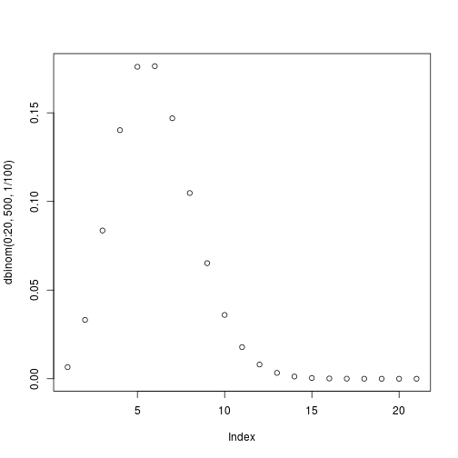

```r
plot(dbinom(0:20, 500, 1/100))
```

How do we use this to decide when a bin contains outliers? If the distance between reads are such that it is unlikely that the only source of errors is the read errors. So the question now becomes:

What is the probability that the distance between two reads is 0 given the only source of discrepancies is the read errors. This is the probability that neither read contains any errors plus the chance that the two reads has exactly the same read errors. The chance of exactly the same read errors occurring are complicating the matter and the chance of that happening is small, so lets ignore that for now.

Hence the question becomes: “What is the chance of there being 0 read errors in a read of length 1000 when the chance of a read error is 1/100.

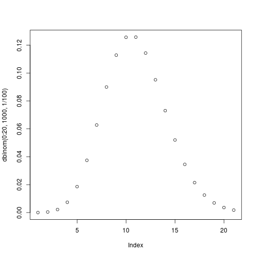

```r
plot(dbinom(0:20, 1000, 1/100))
```

Now, how many read errors can be allowed in a bin before we consider it to be suspicious? If the chance is less than 5% of there being that many read errors, then we should suspect alternative error sources. So lets assume a bin of size two. We just have to find the 95th percentile of the distribution and we are done.

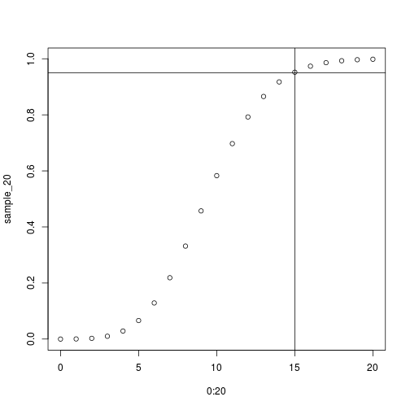

```r
sample_20 <- pbinom(0:20, 1000, 1/100)
plot(x = 0:20, y=sample_20)
abline(h=0.95)
dist_95 <- abs(sample_20-0.95)
closest_95 <- (0:20)[which(dist_95 == min(dist_95))]
abline(v=closest_95)
```

Now, consider the problematic case where there are more than two sequences in the bins. Now the question becomes, What is the probability that the largest and second largest order statistic of a random sample from a binomial distribution is distance x from each other. The distributions of the order statistics are significantly more complex than the binomial distribution.

How can you prove this point? Consider the cases where the only source of distance between sequences are the read errors. Now think what will happen as the bin size approaches infinity? For any given number x, there will exist a number y so that if the bin size exceeds y, the probability of there being a read with more than x errors will exceed say 50%. So this demonstrates that even if the only source of distance between sequences is read errors, there will be a big bin size at which any absolute threshold is exceeded.

Now the question is how significant is this effect?

First we need to compute some order statistics. See http://en.wikipedia.org/wiki/Order_statistic

```r
p1f <- function(x, n, p){
  pbinom(x, n, p) - dbinom(x, n, p)
}

p2f <- function(x, n, p){
  dbinom(x, n, p)
}

p3f <- function(x, n, p){
  1 - pbinom(x, n, p)
}

ord_F <- function(x, k, o_n, n, p){
  p1 <- p1f(x, n, p)
  p2 <- p2f(x, n, p)
  p3 <- p3f(x, n, p)
  summ <- 0
  for (j in 0:(o_n-k)){
    summ <- summ + choose(o_n, j) * p3^j * (p1+p2)^(o_n-j)
  }
  summ
}
```

So lets just look at the maximum order statistic and systematically increase the number of reads in the bin:

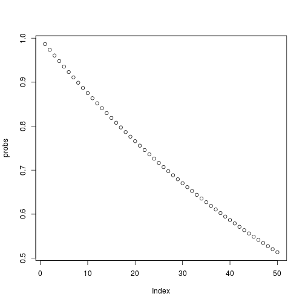

```r
probs <- rep(0, 50)
for (i in 1:50){
  probs[i] <- ord_F(10, i, i, 500, 1/100)
}
plot(probs)
```

What does this mean? This means that the probability of the sequence with the most read errors in it having 10 or less read errors? If your bin is of size 1, then it is extremely likely that the read of the most read errors will have less then 10 read errors. However, if your bin is of size 50, then there is about a 1 in 2 chance of it having less than 10 read errors.

Lets draw the distribution function of a few of the order statistics:

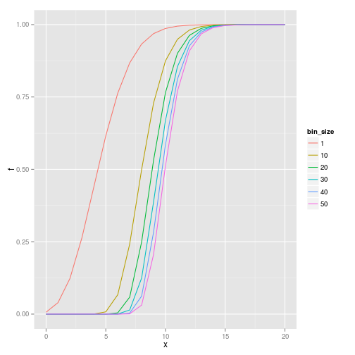

```r
probs <- data.frame(bin_size = numeric(0),
                    x = numeric(0),
                    f = numeric(0))

for (j in c(1, 10, 20, 30, 40, 50)){
  for (i in 0:20){
    probs <- rbind(probs,
                   data.frame(bin_size = j,
                              x = i,
                              f = ord_F(i, j, j, 500, 1/100)))
  }
}
probs$bin_size <- as.factor(probs$bin_size)
ggplot(data = probs, aes(x = x, y = f, col = bin_size)) + geom_line()
```

Now, we need to ask the question: "Are we concerned that we might be chucking out properly labelled reads with lots of read errors, or do we just want to make the job of the aligner as easy as possible?”

Until I can get some input from Colin/Simon I will just implement a very simple absolute threshold based approach and use that as a comparator to my current techniques.

## Ambiguity based subpopulation detection

We can use the number of ambiguity characters in the consensus string to determine whether or not there are two or more subpopulations in the dataset.

We can compute the number of ambiguity characters expected if the only source of variation was the sequencing process and then compare the observed number of ambiguity characters to this and base our decisions on this.

Under the assumption that the only source of variation is read errors, the chance of an ambiguity character at a given position in a 4 read bin is: P(no mutation at position in 2 seq and the same mutation at that position in the other two sequences) + P(1 mutation in two sequences and a different mutation in the two other sequences)

So call this P(none+1) and P(1+another)

P(none+1) = P(any of the sequences has no mutation) x P(another sequence has no mutation) x P(another sequence has a mutation) x P(remaining sequences has the same mutation) = (4c1x(99/100)) x (3c1x(99/100)) x (2c1x(1/100)) x (1c1x(1/100)x(1/3)) = choose(4,1)*(99/100) * choose(3,1)*(99/100) * choose(2,1)*(1/100) * choose(1,1)*(1/100)*(1/3)

Likewise: P(1+another) = P(any of the sequences has mutation 1) x P(another of the sequences has mutation 1) x P(another of the sequences has mutation 2) x P(the last sequence has mutation 2) = (4c1x(1/100)) x (3c1x(1/100)x(1/3)) x (2c1x(1/100)x(2/3)) x (1c1x(1/100)x(1/3)) = choose(4,1)*(1/100) * choose(3,1)*(1/100)*(1/3) * choose(2,1)*(1/100)*(2/3) * choose(1,1)*(1/100)*(1/3)*1

```r
p_none_plus_1 <- choose(4,1)*(99/100) * choose(3,1)*(99/100) *
    choose(2,1)*(1/100) * choose(1,1)*(1/100)*(1/3)

p_1_plus_another <- choose(4,1)*(1/100) * choose(3,1)*(1/100)*(1/3) *
    choose(2,1)*(1/100)*(2/3) * choose(1,1)*(1/100)*(1/3)*1

p_single_pos_amb <- p_none_plus_1 + p_1_plus_another
```

Now, using this result we can compute the probabilty distribution of ambiguity characters arising in the bin using a binomial distribution:

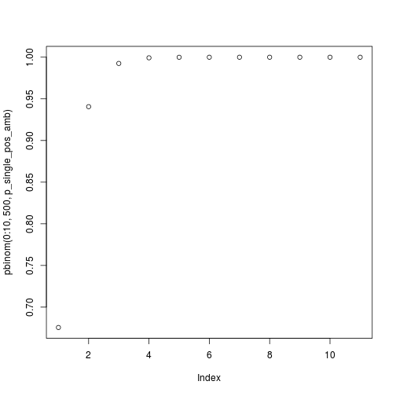

```r
plot(pbinom(0:10, 500, p_single_pos_amb))
```

## Clustering based subpopulation detection

After removing outliers, run clustering on the distance matrices. Use NBClust to detect number of clusters and then pick the largest cluster(s). If more than one cluster, pick the tightest cluster. http://www.jstatsoft.org/v61/i06/paper

Always pick at least 2 clusters.